# Hw 8. Matplotlib

```python
import numpy as np
import matplotlib.pylab as plt
```

## Simple Pendulum!

The main reason we are exploring this relationship instead of looking for the solution of the simple pendulum is that we are very used to things without discuss them.

Here we want to see how well the small angle approximation works. (Specially for this approximation).

The easiest way to understand the approximation is to compare the plots of the two functions we are approximating, (This particular case is also gotten from taking the 1st order Taylor expansion on zero of the $\sin(\theta)$ function).

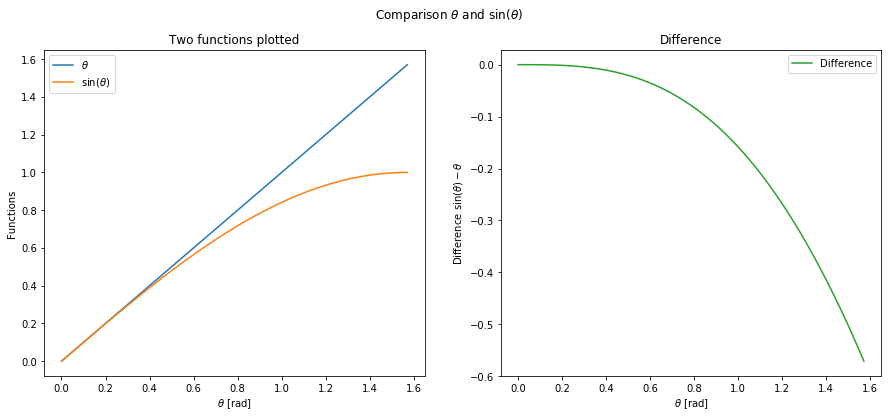

```python
theta=np.linspace(0,np.pi/2.,1000)
fig=plt.figure(figsize=(15,6))
ax1=fig.add_subplot(121)
ax2=fig.add_subplot(122)
ax1.plot(theta,theta,label='$\\theta$')
ax1.plot(theta,np.sin(theta),label='$\sin(\\theta)$')
ax1.legend()
ax1.set_title('Two functions plotted')
ax1.set_xlabel('$\\theta$ [rad]')
ax1.set_ylabel('Functions')
ax2.plot(theta,np.sin(theta)-theta, color='C2',label='Difference')
ax2.set_title('Difference')
ax2.set_xlabel('$\\theta$ [rad]')
ax2.set_ylabel('Difference $\sin(\\theta)-\\theta$')
ax2.legend()
fig.suptitle('Comparison $\\theta$ and $\sin(\\theta)$')
plt.show()
```

Graphically, one can see that they are *almost* the same for $\theta\approx 0.5$ rad, which correspond $\approx 30 $deg. (which at least for me, it is not very small!).

## Dumped Pendulum

This data, are the result from a simulation of a dumped pendulum, we expect to have a exponentially decreasing oscilating function.

```python
url1="https://raw.githubusercontent.com/jmsevillam/Herramientas-Computacionales-UniAndes/master/Data/dumped.dat"
```

```python
Dumped=np.genfromtxt(url1).T
```

```python
Time,theta1,omega1,theta2,omega2=Dumped
```

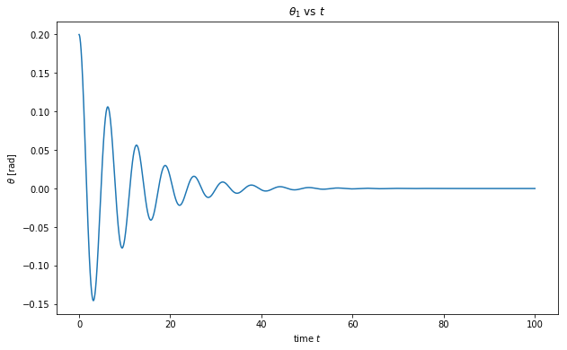

```python
fig=plt.figure(figsize=(10,6))
ax=fig.add_subplot(111)
ax.set_title('$\\theta_1$ vs $t$')
ax.set_ylabel('$\\theta$ [rad]')
ax.set_xlabel('time $t$')
ax.plot(Time,theta1)
plt.show()
```

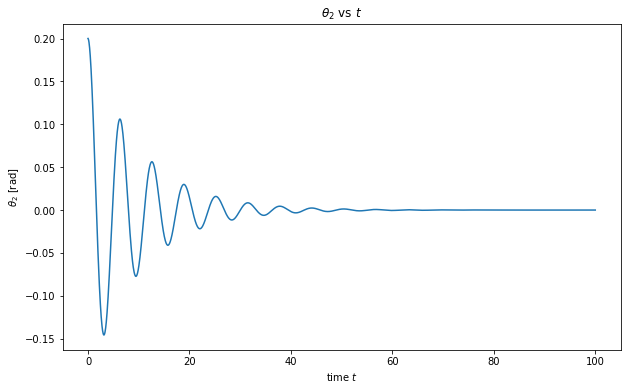

```python
fig=plt.figure(figsize=(10,6))
ax=fig.add_subplot(111)
ax.set_title('$\\theta_2$ vs $t$')
ax.set_ylabel('$\\theta_2$ [rad]')
ax.set_xlabel('time $t$')
ax.plot(Time,theta2)
plt.show()
```

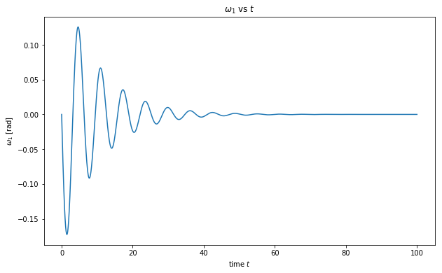

```python
fig=plt.figure(figsize=(10,6))
ax=fig.add_subplot(111)
ax.set_title('$\omega_1$ vs $t$')
ax.set_ylabel('$\\omega_1$ [rad]')
ax.set_xlabel('time $t$')
ax.plot(Time,omega1)
plt.show()
```

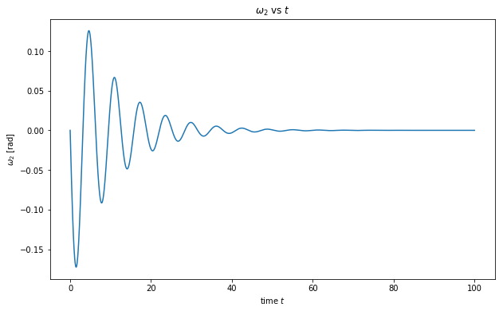

```python
fig=plt.figure(figsize=(10,6))
ax=fig.add_subplot(111)
ax.set_title('$\omega_2$ vs $t$')
ax.set_ylabel('$\\omega_2$ [rad]')
ax.set_xlabel('time $t$')
ax.plot(Time,omega2)
plt.show()
```

### Phase spaces

On this case the phase spaces look very similar!

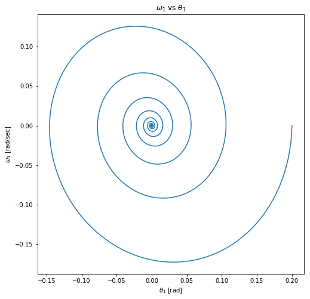

```python
fig=plt.figure(figsize=(8,8))
ax=fig.add_subplot(111)
ax.set_title('$\omega_1$ vs $\\theta_1$')
ax.set_ylabel('$\\omega_1$ [rad/sec]')
ax.set_xlabel('$\\theta_1$ [rad]')
ax.plot(theta2,omega2)
plt.show()
```

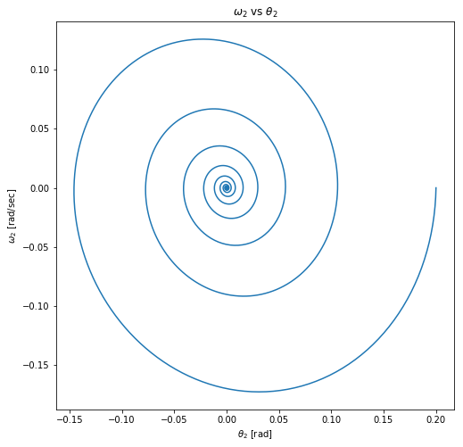

```python
fig=plt.figure(figsize=(8,8))
ax=fig.add_subplot(111)
ax.set_title('$\omega_2$ vs $\\theta_2$')
ax.set_ylabel('$\\omega_2$ [rad/sec]')
ax.set_xlabel('$\\theta_2$ [rad]')
ax.plot(theta2,omega2)
plt.show()
```

It is common to have two different similar initial conditions and evaluate their difference over time in order to evaluate the chaos.

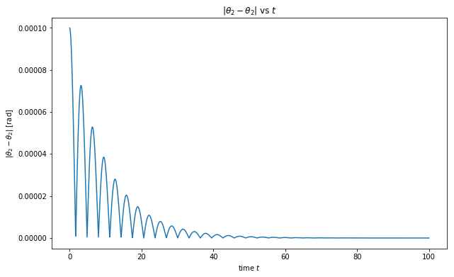

```python
fig=plt.figure(figsize=(10,6))
ax=fig.add_subplot(111)
ax.set_title('$|\\theta_2-\\theta_2|$ vs $t$')
ax.set_ylabel('$|\\theta_2-\\theta_2|$ [rad]')
ax.set_xlabel('time $t$')
ax.plot(Time,np.abs(theta2-theta1))
plt.show()
```

As this relationship looks exponential, one can take el logarithm.

If this difference decrease the system is not chaotic (On this regime).

One can calculate the exponent of this behaviour, this exponent recieves the name of [Lyapunov Exponent](https://en.wikipedia.org/wiki/Lyapunov_exponent)

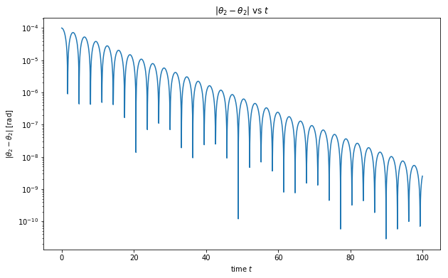

```python
fig=plt.figure(figsize=(10,6))
ax=fig.add_subplot(111)
ax.set_title('$|\\theta_2-\\theta_2|$ vs $t$')
ax.set_ylabel('$|\\theta_2-\\theta_2|$ [rad]')
ax.set_xlabel('time $t$')
ax.set_yscale("log")
ax.plot(Time,np.abs(theta2-theta1))
plt.show()
```

## Driven Pendulum

The case of having a strong (also oscillating) external force, makes the system change dramatically.

The following plots should be calculated from $(0,2\pi)$ or $(-\pi,\pi)$, but we are not going to worry about that.

```python
url2="https://raw.githubusercontent.com/jmsevillam/Herramientas-Computacionales-UniAndes/master/Data/Driven.dat"
```

```python
Driven=np.genfromtxt(url2).T
```

```python
Timeb,theta1b,omega1b,theta2b,omega2b=Driven
```

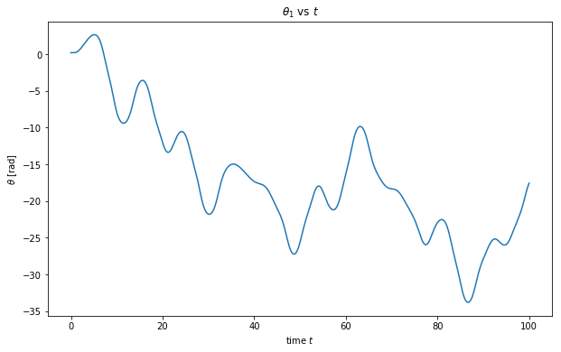

```python
fig=plt.figure(figsize=(10,6))
ax=fig.add_subplot(111)
ax.set_title('$\\theta_1$ vs $t$')
ax.set_ylabel('$\\theta$ [rad]')
ax.set_xlabel('time $t$')
ax.plot(Timeb,theta1b)
plt.show()
```

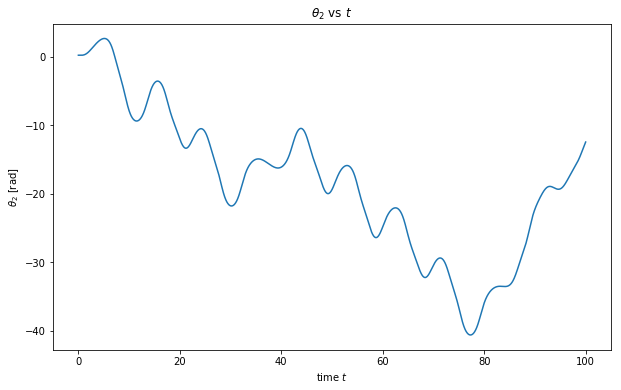

```python
fig=plt.figure(figsize=(10,6))
ax=fig.add_subplot(111)
ax.set_title('$\\theta_2$ vs $t$')
ax.set_ylabel('$\\theta_2$ [rad]')
ax.set_xlabel('time $t$')
ax.plot(Timeb,theta2b)
plt.show()
```

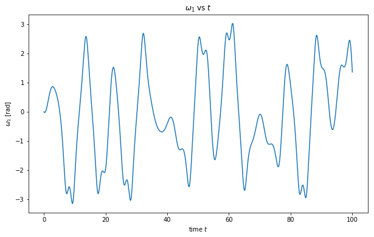

```python
fig=plt.figure(figsize=(10,6))
ax=fig.add_subplot(111)
ax.set_title('$\omega_1$ vs $t$')
ax.set_ylabel('$\\omega_1$ [rad]')
ax.set_xlabel('time $t$')
ax.plot(Timeb,omega1b)
plt.show()
```

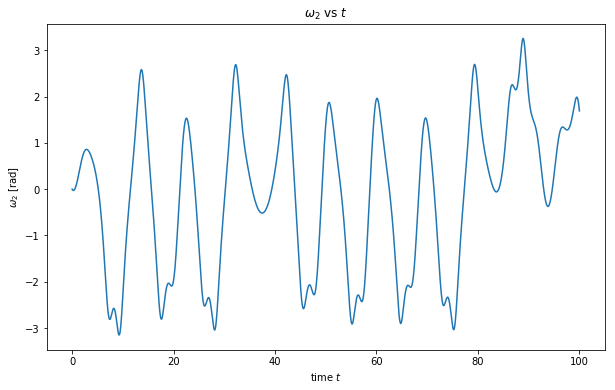

```python
fig=plt.figure(figsize=(10,6))
ax=fig.add_subplot(111)
ax.set_title('$\omega_2$ vs $t$')
ax.set_ylabel('$\\omega_2$ [rad]')
ax.set_xlabel('time $t$')
ax.plot(Timeb,omega2b)
plt.show()
```

### Phase Spaces

On this phase spaces the trajectories cross each other because of the external force.

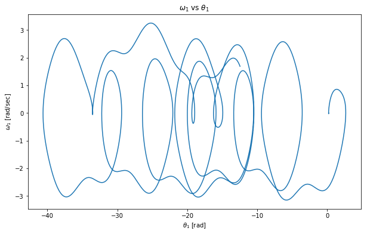

```python
fig=plt.figure(figsize=(10,6))
ax=fig.add_subplot(111)
ax.set_title('$\omega_1$ vs $\\theta_1$')
ax.set_ylabel('$\\omega_1$ [rad/sec]')
ax.set_xlabel('$\\theta_1$ [rad]')
ax.plot(theta2b,omega2b)
plt.show()
```

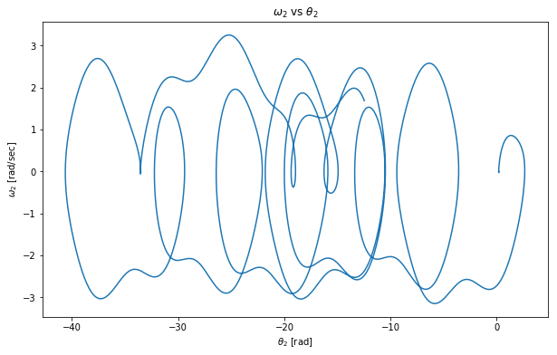

```python
fig=plt.figure(figsize=(10,6))
ax=fig.add_subplot(111)
ax.set_title('$\omega_2$ vs $\\theta_2$')
ax.set_ylabel('$\\omega_2$ [rad/sec]')
ax.set_xlabel('$\\theta_2$ [rad]')
ax.plot(theta2b,omega2b)
plt.show()
```

And the differences look way different.

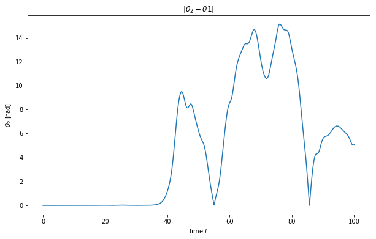

```python
fig=plt.figure(figsize=(10,6))
ax=fig.add_subplot(111)
ax.set_title('$|\\theta_2-\\theta1|$')
ax.set_ylabel('$\\theta_2$ [rad]')
ax.set_xlabel('time $t$')
ax.plot(Timeb,np.abs(theta2b-theta1b))
plt.show()
```

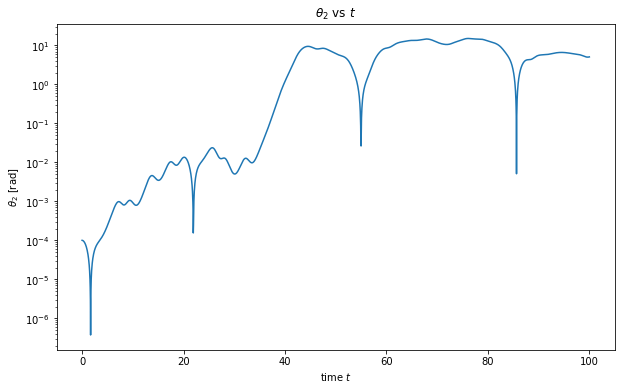

```python
fig=plt.figure(figsize=(10,6))
ax=fig.add_subplot(111)
ax.set_title('$\\theta_2$ vs $t$')
ax.set_ylabel('$\\theta_2$ [rad]')
ax.set_xlabel('time $t$')
ax.set_yscale("log")
ax.plot(Timeb,np.abs(theta2b-theta1b))
plt.show()
```

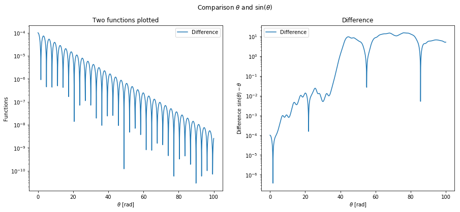

```python
fig=plt.figure(figsize=(15,6))
ax1=fig.add_subplot(121)
ax2=fig.add_subplot(122)

ax1.set_yscale("log")
ax1.set_title('Two functions plotted')
ax1.set_xlabel('$\\theta$ [rad]')
ax1.set_ylabel('Functions')
ax1.plot(Time,np.abs(theta1-theta2),label='Difference')
ax1.legend()

ax2.set_yscale("log")
ax2.set_title('Difference')
ax2.set_xlabel('$\\theta$ [rad]')
ax2.set_ylabel('Difference $\sin(\\theta)-\\theta$')
ax2.plot(Timeb,np.abs(theta1b-theta2b),label='Difference')
ax2.legend()

fig.suptitle('Comparison $\\theta$ and $\sin(\\theta)$')
plt.show()
```

## Driven Pendulum***

As angles are limited (from $0$ to $2\pi$ or from $-\pi$ to $\pi$), one can correct these previous result by transforming the data.

```python
url2="https://raw.githubusercontent.com/jmsevillam/Herramientas-Computacionales-UniAndes/master/Data/Driven.dat"
```

```python
Driven=np.genfromtxt(url2).T
```

```python
Timeb,theta1b,omega1b,theta2b,omega2b=Driven
theta1b=(theta1b+np.pi)%(2*np.pi)
theta2b=(theta2b+np.pi)%(2*np.pi)
```

And repeating everything we get,

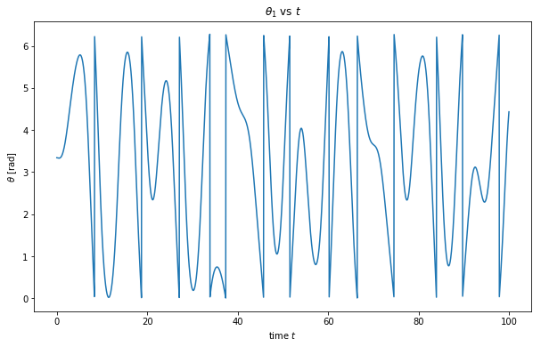

```python
fig=plt.figure(figsize=(10,6))
ax=fig.add_subplot(111)
ax.set_title('$\\theta_1$ vs $t$')
ax.set_ylabel('$\\theta$ [rad]')
ax.set_xlabel('time $t$')
ax.plot(Timeb,theta1b)
plt.show()
```

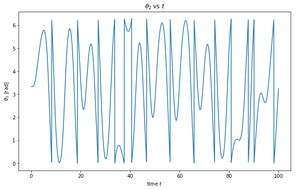

```python
fig=plt.figure(figsize=(10,6))
ax=fig.add_subplot(111)
ax.set_title('$\\theta_2$ vs $t$')
ax.set_ylabel('$\\theta_2$ [rad]')
ax.set_xlabel('time $t$')
ax.plot(Timeb,theta2b)
plt.show()
```

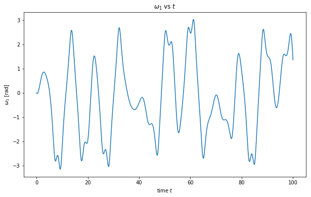

```python
fig=plt.figure(figsize=(10,6))
ax=fig.add_subplot(111)
ax.set_title('$\omega_1$ vs $t$')
ax.set_ylabel('$\\omega_1$ [rad]')
ax.set_xlabel('time $t$')
ax.plot(Timeb,omega1b)
plt.show()
```

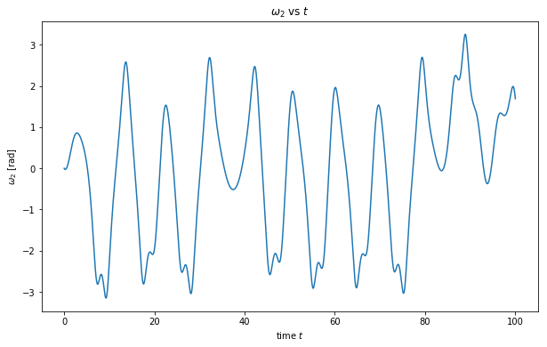

```python
fig=plt.figure(figsize=(10,6))
ax=fig.add_subplot(111)
ax.set_title('$\omega_2$ vs $t$')
ax.set_ylabel('$\\omega_2$ [rad]')
ax.set_xlabel('time $t$')
ax.plot(Timeb,omega2b)
plt.show()
```

### Phase Spaces

New visualization of the phase spaces (They are cylinders)

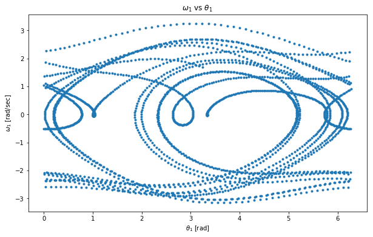

```python
fig=plt.figure(figsize=(10,6))
ax=fig.add_subplot(111)
ax.set_title('$\omega_1$ vs $\\theta_1$')
ax.set_ylabel('$\\omega_1$ [rad/sec]')
ax.set_xlabel('$\\theta_1$ [rad]')
ax.plot(theta2b,omega2b,'.')
plt.show()
```

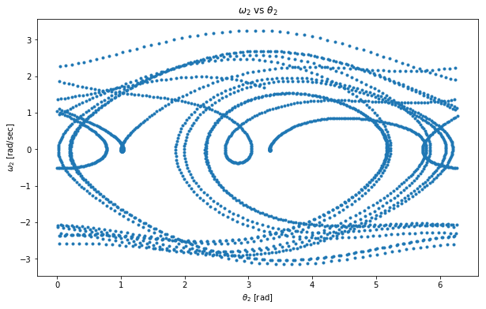

```python
fig=plt.figure(figsize=(10,6))
ax=fig.add_subplot(111)
ax.set_title('$\omega_2$ vs $\\theta_2$')
ax.set_ylabel('$\\omega_2$ [rad/sec]')
ax.set_xlabel('$\\theta_2$ [rad]')
ax.plot(theta2b,omega2b,'.')
plt.show()
```

And more drastic behaviour

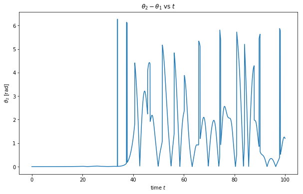

```python
fig=plt.figure(figsize=(10,6))
ax=fig.add_subplot(111)
ax.set_title('$\\theta_2-\\theta_1$ vs $t$')
ax.set_ylabel('$\\theta_2$ [rad]')
ax.set_xlabel('time $t$')
ax.plot(Timeb,np.abs(theta2b-theta1b))
plt.show()
```

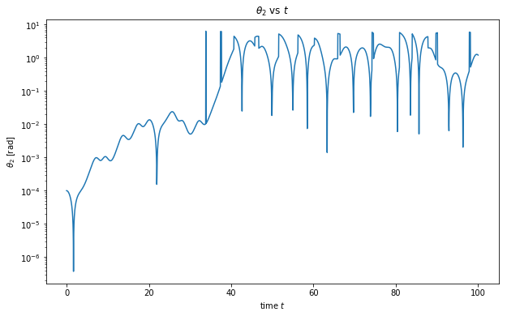

```python
fig=plt.figure(figsize=(10,6))
ax=fig.add_subplot(111)
ax.set_title('$\\theta_2$ vs $t$')
ax.set_ylabel('$\\theta_2$ [rad]')
ax.set_xlabel('time $t$')
ax.set_yscale("log")
ax.plot(Timeb,np.abs(theta2b-theta1b))
plt.show()
```

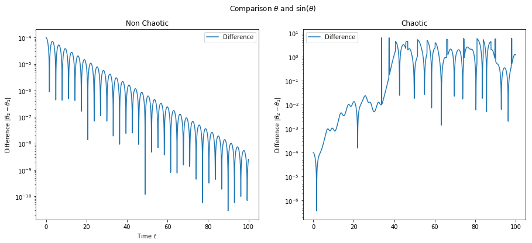

```python
fig=plt.figure(figsize=(15,6))
ax1=fig.add_subplot(121)
ax2=fig.add_subplot(122)

ax1.set_yscale("log")
ax1.set_title('Non Chaotic')
ax1.set_xlabel('Time $t$')
ax1.set_ylabel('Difference $|\\theta_2-\\theta_1|$')
ax1.plot(Time,np.abs(theta1-theta2),label='Difference')
ax1.legend()

ax2.set_yscale("log")
ax2.set_title('Chaotic')
ax1.set_xlabel('Time $t$')
ax2.set_ylabel('Difference $|\\theta_2-\\theta_1|$')
ax2.plot(Timeb,np.abs(theta1b-theta2b),label='Difference')
ax2.legend()

fig.suptitle('Comparison $\\theta$ and $\sin(\\theta)$')
plt.show()
```

## Light on a Mirror

This simulation shows the intensity pattern of a plane *light* which travels towards a spherical mirror, as the mirror has a focus depending on its curvature, the intensity will be higher on that point

```python
url3="https://raw.githubusercontent.com/jmsevillam/Herramientas-Computacionales-UniAndes/master/Data/LBWaves.dat"
```

```python
Mirror=np.genfromtxt(url3)
```

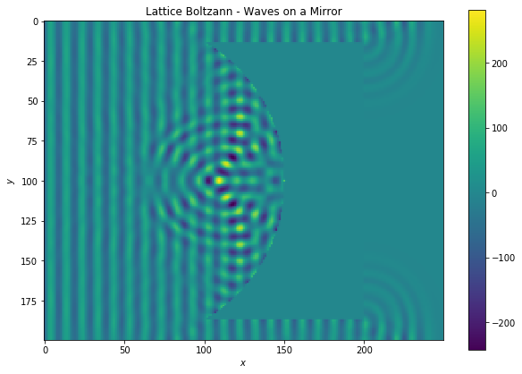

```python
fig=plt.figure(figsize=(10,7))
ax=fig.add_subplot(111)
ax.set_aspect("equal")
ax.set_title('Lattice Boltzann - Waves on a Mirror')
ax.set_ylabel('$y$')
ax.set_xlabel('$x$')
pl=ax.imshow(Mirror)
plt.colorbar(pl)
plt.show()
```

```python
np.unravel_index(np.argmax(Mirror, axis=None), Mirror.shape)
```

```
(100, 109)
```

## Taylor Works

We are going to explore how Taylor expansions work in the particular case of the sine function.

```python
def fac(n):
    if n==0 or n==1:
        return 1
    else:
        return n*fac(n-1)

def sin_tay(n,x):
    suma=np.zeros(len(x))
    for i in range(n):
        suma+=(-1.)**i/fac(2.*i+1)*x**(2.*i+1.)
    return suma
```

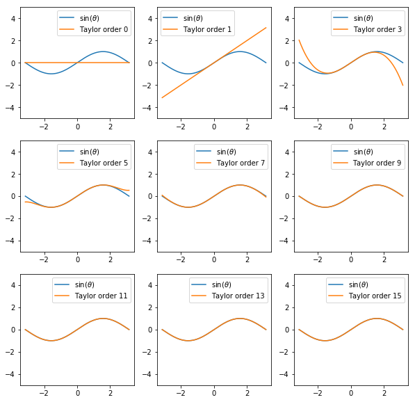

```python
x=np.linspace(-np.pi,np.pi,1000)
fig=plt.figure(figsize=(10,10))
for i in range(0,9):
    ax=fig.add_subplot(3,3,i+1)
    ax.plot(x,np.sin(x),label='$\sin(\\theta)$')
    y=sin_tay(i,x)
    index=2*i-1
    if index<0: index=0
    ax.plot(x,y,label='Taylor order '+str(index))
    ax.set_ylim(-5,5)
    ax.legend()
plt.show()
```

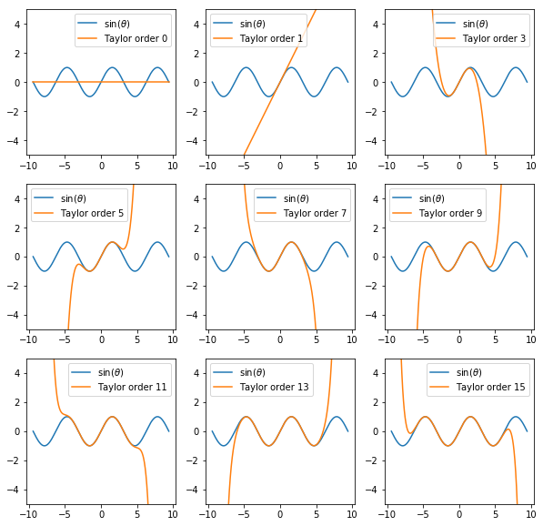

```python
x=np.linspace(-3*np.pi,3*np.pi,1000)
fig=plt.figure(figsize=(10,10))
for i in range(0,9):
    ax=fig.add_subplot(3,3,i+1)
    ax.plot(x,np.sin(x),label='$\sin(\\theta)$')
    y=sin_tay(i,x)
    index=2*i-1
    if index<0: index=0
    ax.plot(x,y,label='Taylor order '+str(index))
    ax.set_ylim(-5,5)
    ax.legend()
plt.show()
```